# Sumativa 3 – Fase 3

Optimización del OEE mediante Mantenimiento Predictivo

## Integrantes:

- Alana Bermúdez
- Gonzalo Mansilla
- Eduardo Villalón

## Curso: MCDI500

## Contexto y base del proyecto (Fase 3)

## Propósito del notebook

Este notebook se construye a partir del trabajo desarrollado en la Fase 3 (Formativa 3), donde se implementaron algoritmos recursivos y análisis de complejidad utilizando el dataset procesado en Fase 2.

En esta etapa (Sumativa 3), se extiende dicho trabajo incorporando una estructura más robusta basada en programación estructurada y Programación Orientada a Objetos (POO), junto con validaciones y análisis de eficiencia.

Este enfoque permite avanzar desde un prototipo funcional hacia una solución más estructurada, reutilizable y escalable para el análisis de datos.

## Estructura del flujo y funciones principales

En esta sección se reorganiza el flujo del notebook mediante funciones estructuradas que permiten separar responsabilidades como la carga de datos, validación y preparación de información.

Este enfoque facilita la reutilización del código y su posterior extensión mediante Programación Orientada a Objetos.

```python
import sys
import os
from pathlib import Path
import pandas as pd
import numpy as np

# Asegurar que Python encuentre los archivos en la raíz
sys.path.append(os.path.abspath('..'))

# Dejamos los imports originales (sin obtener_raiz_proyecto)
from src.carga_validacion import cargar_dataset_procesado, validar_dataset_f3
from src.procesamiento import Preprocesador

print("Configuración cargada correctamente: Módulos listos para uso.")
```

```
Configuración cargada correctamente: Módulos listos para uso.
```

```python
def obtener_raiz_proyecto() -> Path:
    """
    Identifica la raíz del proyecto según la ubicación desde donde se ejecuta el notebook.
    """
    cwd = Path.cwd()
    if (cwd / "data").exists():
        return cwd
    if (cwd.parent / "data").exists():
        return cwd.parent
    raise FileNotFoundError("No se pudo identificar la raíz del proyecto.")

# Ejecución de las rutas usando la función de arriba
PROJECT_ROOT = obtener_raiz_proyecto()
DATA_PROCESSED = PROJECT_ROOT / "data" / "processed" / "dataset_procesado.csv"

print("Raíz del proyecto:", PROJECT_ROOT)
print("Dataset procesado:", DATA_PROCESSED)
```

```
Raíz del proyecto: c:\Users\alana\mcdi500_s1_grupo7
Dataset procesado: c:\Users\alana\mcdi500_s1_grupo7\data\processed\dataset_procesado.csv
```

```python
df = cargar_dataset_procesado(DATA_PROCESSED)
df.head()
```

|  | date | device | failure | metric1 | metric2 | metric3 | metric4 | metric5 | metric6 | metric7 | metric8 | metric9 | year | month | day |
| --- | --- | --- | --- | --- | --- | --- | --- | --- | --- | --- | --- | --- | --- | --- | --- |
| 0 | 2015-01-01 | S1F01085 | 0 | 215630672 | 55 | 0 | 52 | 6 | 407438 | 0 | 0 | 7 | 2015 | 1 | 1 |
| 1 | 2015-01-01 | S1F0166B | 0 | 61370680 | 0 | 3 | 0 | 6 | 403174 | 0 | 0 | 0 | 2015 | 1 | 1 |
| 2 | 2015-01-01 | S1F01E6Y | 0 | 173295968 | 0 | 0 | 0 | 12 | 237394 | 0 | 0 | 0 | 2015 | 1 | 1 |
| 3 | 2015-01-01 | S1F01JE0 | 0 | 79694024 | 0 | 0 | 0 | 6 | 410186 | 0 | 0 | 0 | 2015 | 1 | 1 |
| 4 | 2015-01-01 | S1F01R2B | 0 | 135970480 | 0 | 0 | 0 | 15 | 313173 | 0 | 0 | 3 | 2015 | 1 | 1 |

```python
validar_dataset_f3(df)
print("Validaciones automáticas F3: OK")
```

```
Validaciones automáticas F3: OK
```

```python
def resumen_dataset_f3(df: pd.DataFrame) -> pd.DataFrame:
    """
    Genera un resumen técnico del dataset utilizado como insumo para Fase 3.
    """
    resumen = pd.DataFrame({
        "criterio": [
            "Filas",
            "Columnas",
            "Valores nulos",
            "Duplicados",
            "Fecha mínima",
            "Fecha máxima",
            "Dispositivos únicos",
            "Eventos de falla",
            "Registros sin falla"
        ],
        "resultado": [
            df.shape[0],
            df.shape[1],
            int(df.isnull().sum().sum()),
            int(df.duplicated().sum()),
            df["date"].min(),
            df["date"].max(),
            df["device"].nunique(),
            int(df["failure"].sum()),
            int((df["failure"] == 0).sum())
        ]
    })

    return resumen

resumen_f3 = resumen_dataset_f3(df)
resumen_f3
```

|  | criterio | resultado |
| --- | --- | --- |
| 0 | Filas | 124493 |
| 1 | Columnas | 15 |
| 2 | Valores nulos | 0 |
| 3 | Duplicados | 0 |
| 4 | Fecha mínima | 2015-01-01 00:00:00 |
| 5 | Fecha máxima | 2015-11-02 00:00:00 |
| 6 | Dispositivos únicos | 1169 |
| 7 | Eventos de falla | 106 |
| 8 | Registros sin falla | 124387 |

## Validación inicial del dataset para Fase 3

El dataset utilizado en esta fase corresponde al archivo procesado en Fase 2. No se reconstruye el pipeline de limpieza, ya que el objetivo de la Formativa 3 es avanzar hacia el diseño de algoritmos, recursividad y mediciones de complejidad.

La validación inicial confirma que el dataset mantiene las condiciones esperadas: ausencia de valores nulos, ausencia de duplicados, columna `date` en formato temporal, presencia de variables derivadas `year`, `month` y `day`, y variable objetivo binaria `failure`.

Estas condiciones permiten continuar con las actividades de los otros integrantes del equipo: implementación de algoritmos estructurados, comparación de eficiencia y desarrollo de un algoritmo recursivo.

```python
SRC_PATH = PROJECT_ROOT / "F3" / "src"

if str(SRC_PATH) not in sys.path:
    sys.path.append(str(SRC_PATH))

#from carga_validacion import cargar_dataset_procesado, validar_dataset_f3

#df_prueba = cargar_dataset_procesado(DATA_PROCESSED)
#validar_dataset_f3(df_prueba)

print("Importación desde script F3: OK")
```

```
Importación desde script F3: OK
```

```python
import pandas as pd
from pathlib import Path

# Ruta directa al dataset procesado
ruta = Path.cwd().parent / "data" / "processed" / "dataset_procesado.csv"

df_prueba = pd.read_csv(ruta)

print("Dataset cargado correctamente ✅")
df_prueba.head()
```

```
Dataset cargado correctamente ✅
```

|  | date | device | failure | metric1 | metric2 | metric3 | metric4 | metric5 | metric6 | metric7 | metric8 | metric9 | year | month | day |
| --- | --- | --- | --- | --- | --- | --- | --- | --- | --- | --- | --- | --- | --- | --- | --- |
| 0 | 2015-01-01 | S1F01085 | 0 | 215630672 | 55 | 0 | 52 | 6 | 407438 | 0 | 0 | 7 | 2015 | 1 | 1 |
| 1 | 2015-01-01 | S1F0166B | 0 | 61370680 | 0 | 3 | 0 | 6 | 403174 | 0 | 0 | 0 | 2015 | 1 | 1 |
| 2 | 2015-01-01 | S1F01E6Y | 0 | 173295968 | 0 | 0 | 0 | 12 | 237394 | 0 | 0 | 0 | 2015 | 1 | 1 |
| 3 | 2015-01-01 | S1F01JE0 | 0 | 79694024 | 0 | 0 | 0 | 6 | 410186 | 0 | 0 | 0 | 2015 | 1 | 1 |
| 4 | 2015-01-01 | S1F01R2B | 0 | 135970480 | 0 | 0 | 0 | 15 | 313173 | 0 | 0 | 3 | 2015 | 1 | 1 |

## Algoritmo Recursivo y Análisis de Complejidad

```python
# Seleccionar columna metric1 y crear muestra de 5000 datos
datos_metric1 = df_prueba["metric1"].head(5000).tolist()

print("Cantidad de elementos en la muestra:", len(datos_metric1))
```

```
Cantidad de elementos en la muestra: 5000
```

```python
# Función merge: combina dos listas ordenadas
def merge(izquierda, derecha):
    resultado = []
    i = j = 0

    # Comparar elementos de ambas listas
    while i < len(izquierda) and j < len(derecha):
        if izquierda[i] < derecha[j]:
            resultado.append(izquierda[i])
            i += 1
        else:
            resultado.append(derecha[j])
            j += 1

    # Agregar elementos restantes
    resultado.extend(izquierda[i:])
    resultado.extend(derecha[j:])

    return resultado
def merge_sort(lista):
    if len(lista) <= 1:
        return lista

    medio = len(lista) // 2
    izquierda = merge_sort(lista[:medio])
    derecha = merge_sort(lista[medio:])

    return merge(izquierda, derecha)

# Probar el algoritmo recursivo con tus 5000 datos guardados
datos_ordenados = merge_sort(datos_metric1)

print("¡Algoritmo ejecutado con éxito! ✅")
print("Primeros 10 elementos ordenados:", datos_ordenados[:10])
```

```
¡Algoritmo ejecutado con éxito! ✅
Primeros 10 elementos ordenados: [0, 9472, 298304, 370600, 444224, 473552, 508584, 543344, 636368, 660440]
```

```python
# Función recursiva Merge Sort
def merge_sort(lista):

    # Caso base: lista de 1 o 0 elementos ya está ordenada
    if len(lista) <= 1:
        return lista

    # Dividir en dos mitades
    medio = len(lista) // 2
    izquierda = lista[:medio]
    derecha = lista[medio:]

    # Llamada recursiva a cada mitad
    izquierda_ordenada = merge_sort(izquierda)
    derecha_ordenada = merge_sort(derecha)

    # Combinar usando merge
    return merge(izquierda_ordenada, derecha_ordenada)
```

```python
# Ejecutar Merge Sort sobre la muestra
ordenado_merge = merge_sort(datos_metric1)

# Mostrar los primeros 10 valores ordenados
print("Primeros 10 valores (Merge Sort):")
print(ordenado_merge[:10])
```

```
Primeros 10 valores (Merge Sort):
[0, 9472, 298304, 370600, 444224, 473552, 508584, 543344, 636368, 660440]
```

```python
# Validar con función nativa de Python
ordenado_python = sorted(datos_metric1)

# Comparar ambos resultados
assert datos_ordenados == ordenado_python

print("✅ Validación exitosa: ambos resultados son iguales")
```

```
✅ Validación exitosa: ambos resultados son iguales
```

```python
import timeit

# Tiempo de ejecución Merge Sort
tiempo_merge = timeit.timeit(
    lambda: merge_sort(datos_metric1.copy()),
    number=5
)

# Tiempo de ejecución sorted()
tiempo_python = timeit.timeit(
    lambda: sorted(datos_metric1.copy()),
    number=5
)

print("Tiempo Merge Sort:", tiempo_merge)
print("Tiempo sorted():", tiempo_python)
```

```
Tiempo Merge Sort: 0.071746700001313
Tiempo sorted(): 0.002358499999900232
```

```python
import pandas as pd

resultados = pd.DataFrame({
    "Algoritmo": ["Merge Sort (Recursivo)", "sorted() (Optimizado)"],
    "Tiempo de ejecución": [tiempo_merge, tiempo_python]
})

resultados
```

|  | Algoritmo | Tiempo de ejecución |
| --- | --- | --- |
| 0 | Merge Sort (Recursivo) | 0.071747 |
| 1 | sorted() (Optimizado) | 0.002358 |

### Interpretación de Resultados

La recursividad es una técnica de programación en la cual una función se llama a sí misma para resolver un problema dividiéndolo en subproblemas más pequeños. En este caso, el algoritmo Merge Sort utiliza este enfoque para ordenar los datos de manera eficiente.

Merge Sort funciona bajo el paradigma de "dividir y conquistar", separando la lista en mitades sucesivas hasta llegar a listas de un solo elemento, las cuales se consideran ordenadas por definición. Luego, estas listas se combinan mediante la función merge, que construye una lista ordenada final.

Desde el punto de vista de complejidad, Merge Sort tiene una complejidad temporal de O(n log n), lo que lo hace eficiente incluso para grandes volúmenes de datos. Sin embargo, su implementación recursiva implica un mayor uso de memoria debido a la pila de llamadas.

Al comparar con la función nativa sorted(), se observa que esta última presenta un mejor rendimiento, ya que está optimizada internamente en Python.

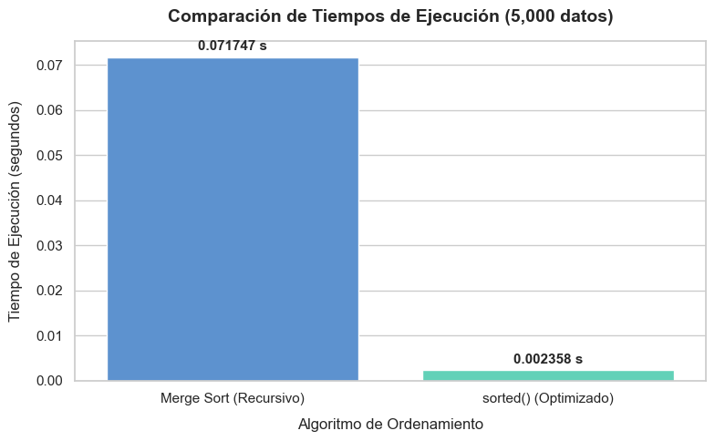

```python
import matplotlib.pyplot as plt
import seaborn as sns

# Configurar el estilo visual
sns.set_theme(style="whitegrid")
plt.figure(figsize=(8, 5))

# Crear el gráfico de barras corregido
ax = sns.barplot(
    x="Algoritmo",
    y="Tiempo de ejecución",
    data=resultados,
    hue="Algoritmo",      # Esta línea elimina la advertencia
    palette=["#4A90E2", "#50E3C2"],
    legend=False          # Esto evita que salga una leyenda redundante
)

# Añadir títulos y etiquetas
plt.title("Comparación de Tiempos de Ejecución (5,000 datos)", fontsize=14, fontweight='bold', pad=15)
plt.xlabel("Algoritmo de Ordenamiento", fontsize=12, labelpad=10)
plt.ylabel("Tiempo de Ejecución (segundos)", fontsize=12, labelpad=10)

# Agregar las etiquetas con el valor exacto sobre cada barra
for p in ax.patches:
    ax.annotate(f"{p.get_height():.6f} s",
                (p.get_x() + p.get_width() / 2., p.get_height()),
                ha='center', va='center',
                xytext=(0, 8),
                textcoords='offset points',
                fontsize=11, fontweight='bold')

plt.tight_layout()
plt.show()
```

### Conclusión

La implementación de Merge Sort permitió aplicar de manera práctica el concepto de recursividad, evidenciando cómo un problema complejo puede resolverse mediante su descomposición en partes más pequeñas. Este enfoque resulta especialmente útil desde una perspectiva formativa, ya que facilita la comprensión de algoritmos de ordenamiento eficientes.

No obstante, en un contexto aplicado al análisis de datos, se observa que el uso de funciones optimizadas como sorted() ofrece mejores tiempos de ejecución y menor sobrecarga de recursos. Por ello, si bien la recursividad es conceptualmente poderosa, su uso en entornos productivos debe evaluarse cuidadosamente, priorizando soluciones que combinen eficiencia, legibilidad y escalabilidad.

## Implementación de flujo estructurado

En esta sección se reorganiza el proceso del análisis mediante un enfoque estructurado basado en funciones, permitiendo separar claramente las etapas de carga, validación y preparación de datos.

Este diseño facilita la mantenibilidad del código y su posterior integración con Programación Orientada a Objetos.

Este enfoque permite además una mejor trazabilidad del flujo de datos, facilitando su análisis y validación en etapas posteriores del proyecto.

```python
def cargar_datos(ruta):
    import pandas as pd

    try:
        df = pd.read_csv(ruta)
        print("✅ Dataset cargado correctamente:", df.shape)
        return df
    except Exception as e:
        print("❌ Error al cargar dataset:", e)
```

```python
def validar_datos(df):
    assert df is not None, "El dataset está vacío"
    assert df.isnull().sum().sum() == 0, "Existen valores nulos"
    assert df.duplicated().sum() == 0, "Existen duplicados"

    print("✅ Validación completada")
```

```python
def preparar_datos(df):
    datos = df["metric1"].head(5000).tolist()
    print("✅ Datos preparados:", len(datos))
    return datos
```

```python
def main():
    df = cargar_datos(DATA_PROCESSED)
    validar_datos(df)
    datos = preparar_datos(df)

    return df, datos
```

```python
# Esto ejecuta todas tus funciones en orden
df, datos = main()

# Esto te muestra que los datos fueron cargados y preparados correctamente
print("Proceso finalizado. El dataset tiene", len(df), "filas.")
print("Tu lista de datos preparada tiene", len(datos), "elementos.")
```

```
✅ Dataset cargado correctamente: (124493, 15)
✅ Validación completada
✅ Datos preparados: 5000
Proceso finalizado. El dataset tiene 124493 filas.
Tu lista de datos preparada tiene 5000 elementos.
```

### Ejecución del flujo principal

La función main() permite coordinar las distintas etapas del flujo estructurado, integrando la carga, validación y preparación del dataset.

Su ejecución permite generar tanto el dataset limpio como la muestra de datos utilizada en el análisis algorítmico.

```python
df_main, datos_main = main()
```

```
✅ Dataset cargado correctamente: (124493, 15)
✅ Validación completada
✅ Datos preparados: 5000
```

```python
df_main.head()
```

|  | date | device | failure | metric1 | metric2 | metric3 | metric4 | metric5 | metric6 | metric7 | metric8 | metric9 | year | month | day |
| --- | --- | --- | --- | --- | --- | --- | --- | --- | --- | --- | --- | --- | --- | --- | --- |
| 0 | 2015-01-01 | S1F01085 | 0 | 215630672 | 55 | 0 | 52 | 6 | 407438 | 0 | 0 | 7 | 2015 | 1 | 1 |
| 1 | 2015-01-01 | S1F0166B | 0 | 61370680 | 0 | 3 | 0 | 6 | 403174 | 0 | 0 | 0 | 2015 | 1 | 1 |
| 2 | 2015-01-01 | S1F01E6Y | 0 | 173295968 | 0 | 0 | 0 | 12 | 237394 | 0 | 0 | 0 | 2015 | 1 | 1 |
| 3 | 2015-01-01 | S1F01JE0 | 0 | 79694024 | 0 | 0 | 0 | 6 | 410186 | 0 | 0 | 0 | 2015 | 1 | 1 |
| 4 | 2015-01-01 | S1F01R2B | 0 | 135970480 | 0 | 0 | 0 | 15 | 313173 | 0 | 0 | 3 | 2015 | 1 | 1 |

```python
# Ejecución del flujo principal
try:
    # Llamamos al orquestador que definiste anteriormente
    df_procesado, lista_datos = main()

    # Imprimimos confirmación
    print("-" * 30)
    print("✅ Flujo principal ejecutado exitosamente.")
    print(f"Dataset con {df_procesado.shape[0]} filas.")
    print(f"Lista para ordenar con {len(lista_datos)} elementos.")

except Exception as e:
    print(f"❌ Error en la ejecución del flujo: {e}")
```

```
✅ Dataset cargado correctamente: (124493, 15)
✅ Validación completada
✅ Datos preparados: 5000
------------------------------
✅ Flujo principal ejecutado exitosamente.
Dataset con 124493 filas.
Lista para ordenar con 5000 elementos.
```

### Visualización del dataset

Se muestran los primeros registros del dataset procesado, verificando que la carga de datos y el flujo estructurado se ejecutaron correctamente.

Esto permite confirmar la integridad de los datos y la correcta ejecución del flujo implementado.

```python
class Preprocesador:
    def __init__(self, df):
        self.df = df

    def prep_preprocesador(self):
        datos = self.df["metric1"].head(5000).tolist()
        print("✅ Datos preparados por POO:", len(datos))
        return datos
```

```python
# Instanciamos la clase pasando el dataframe que ya cargamos
prep = Preprocesador(df_main)

# Llamamos al método de procesamiento
datos_finales = prep.prep_preprocesador()

# Imprimimos para confirmar
print("Los datos están listos para el algoritmo:", len(datos_finales))
```

```
✅ Datos preparados por POO: 5000
Los datos están listos para el algoritmo: 5000
```

### Implementación inicial de POO

Se implementa una clase básica que encapsula el dataset, permitiendo organizar el acceso a los datos mediante métodos.

Este enfoque establece una base para la extensión del proyecto mediante principios de Programación Orientada a Objetos.

Esta implementación permite una futura extensión del sistema mediante herencia y reutilización de componentes dentro del proceso de análisis.

```python
import pandas as pd
import numpy as np
print("Librerías cargadas correctamente.")
```

```
Librerías cargadas correctamente.
```

```python
class Preprocesador:
    """Clase base para la gestión de datasets."""
    def __init__(self, df):
        """Recibe un DataFrame de pandas y lo encapsula como atributo privado."""
        self._df = df  # El guion bajo indica que es un atributo protegido
```

```python
class Transformador(Preprocesador):
    """Clase derivada que extiende a Preprocesador mediante herencia."""
    def __init__(self, df):
        super().__init__(df)

    def imputar_nulos(self, columna, metodo='mean'):
        valor = self._df[columna].mean() if metodo == 'mean' else self._df[columna].median()
        self._df[columna] = self._df[columna].fillna(valor)
        return self

    def escalar_minmax(self, columnas):
        for col in columnas:
            # Validación de seguridad para evitar errores si la columna no existe
            if col not in self._df.columns:
                print(f"⚠️ Advertencia: La columna '{col}' no existe.")
                continue
            min_val = self._df[col].min()
            max_val = self._df[col].max()
            self._df[col] = (self._df[col] - min_val) / (max_val - min_val)
        return self
```

```python
# Crear un DataFrame pequeño con datos nulos
data = pd.DataFrame({'a': [1, 5, np.nan], 'b': [10, 50, 100]})

# Usar tu clase Transformador
t = Transformador(data)
t.imputar_nulos('a', 'mean').escalar_minmax(['a', 'b'])

# Imprimir el resultado final
print("--- DataFrame Procesado ---")
print(t._df)

# Validación final de integridad
nulos_restantes = t._df.isnull().sum().sum()
print(f"\n✅ Total de valores nulos encontrados tras el proceso: {nulos_restantes}")
```

```
--- DataFrame Procesado ---
     a         b
0  0.0  0.000000
1  1.0  0.444444
2  0.5  1.000000

✅ Total de valores nulos encontrados tras el proceso: 0
```

### Resumen de Implementación POO

| Clase | Función | Beneficio |
| --- | --- | --- |
| `Preprocesador` | Encapsulamiento de datos | Organización y seguridad de la información |
| `Transformador` | Herencia y métodos de limpieza | Reutilización de código y escalabilidad |

```python
# Prueba de robustez: Intentar escalar una columna inexistente
print("--- Verificación de Robustez ---")
t.escalar_minmax(['columna_falsa'])
```

```
--- Verificación de Robustez ---
⚠️ Advertencia: La columna 'columna_falsa' no existe.
```

```
<__main__.Transformador at 0x2310f8652b0>
```